# 16S analysis

Megan Boland

3/15/2021

Analysis of 16S sequencing data obtained from anaerobic digesters treating swine wastewater and lignocellulosic biomass. CNTRL: swine wastewater only, WW+SG: swine wastewater and switchgrass, WW+CS: swine wastewater and corn stover. Goal is to identify microbes which may be important for lignocellulose hydrolysis.

Load packages

```r
library(dada2); packageVersion("dada2")
```

```
## [1] '1.16.0'
```

```r
library(phyloseq); packageVersion("phyloseq")
```

```
## [1] '1.32.0'
```

```r
library(Biostrings); packageVersion("Biostrings")
```

```
## [1] '2.56.0'
```

```r
library(decontam); packageVersion("decontam")
```

```
## [1] '1.8.0'
```

```r
library(vegan); packageVersion("vegan")
```

```
## [1] '2.5.7'
```

```r
library(DESeq2); packageVersion("DESeq2")
```

```
## [1] '1.28.1'
```

```r
library(ANCOMBC); packageVersion("ANCOMBC")
```

```
## [1] '1.1.3'
```

```r
source("ancom_v2.1.R")
library(ggordiplots)
library(nlme)
library(ggplot2)
library(dplyr)
library(compositions)
library(ggfortify)
library(readxl)
library(RColorBrewer)
theme_set(theme_bw())
```

## DADA2

Reads were first checked for quality in FastQC and leftover adapters were removed with BBduk. Pipeline follows DADA2 tutorial with slight modifications.

```r
path <- "~/Google Drive/Research/DATA/16S analysis/fastq_clean"
list.files(path)

fnFs <- sort(list.files(path, pattern="_clean_R1.fastq", full.names = TRUE))
fnRs <- sort(list.files(path, pattern="_clean_R2.fastq", full.names = TRUE))

sample.names <- sapply(strsplit(basename(fnFs), "_"), `[`, 1)

filtFs <- file.path(path, "filtered", paste0(sample.names, "_F_filt.fastq.gz"))
filtRs <- file.path(path, "filtered", paste0(sample.names, "_R_filt.fastq.gz"))
names(filtFs) <- sample.names
names(filtRs) <- sample.names
```

Quality profile forward

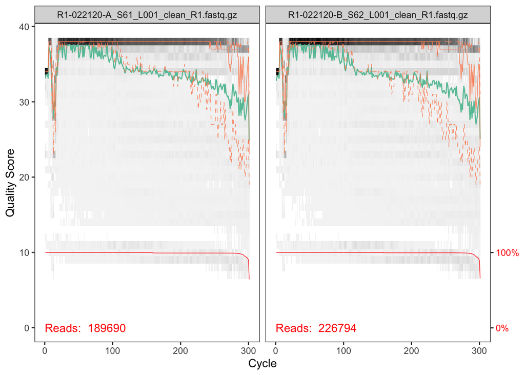

```r
plotQualityProfile(fnFs[7:8])
```

Quality profile reverse

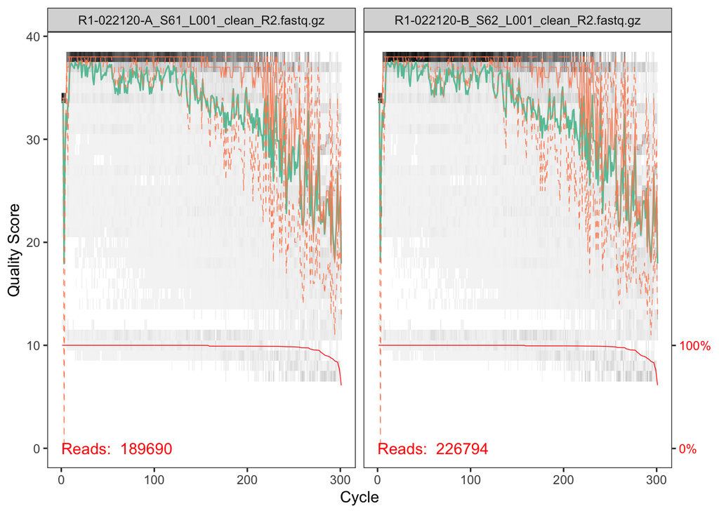

```r
plotQualityProfile(fnRs[7:8])
```

**Filter and trim:** Trim first 20 bp and truncate at 290 bp for forward reads, trim frist 10 bp and truncate a 200 bp for reverse reads.

```r
out <- filterAndTrim(fnFs, filtFs, fnRs, filtRs, trimLeft=c(20,10), truncLen=c(290,200),
                     maxN=0, maxEE=c(2,5), truncQ=2, rm.phix=TRUE,
                     compress=TRUE, multithread=TRUE)

errF <- learnErrors(filtFs, multithread=TRUE)
errR <- learnErrors(filtRs, multithread=TRUE)
```

**Learn error rates:** parametric error model unique to each amplicon dataset. from documentation: learns errors by alternating estimate of the error rates and inference of sample position until the converge on a jointly consistent solution.

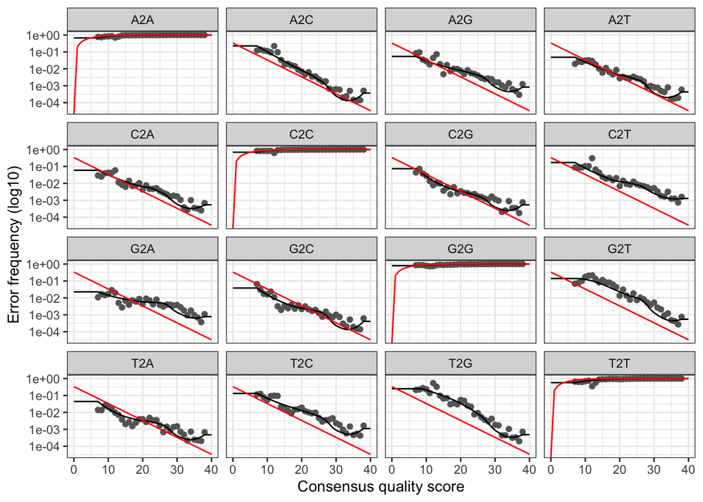

```r
plotErrors(errF, nominalQ=TRUE)
```

Error rates look good: red line shows error rates expected under nominal definition of the Q-score. Black line is estimated error rates and it fits well. (error rates drop with increased quality)

**Sample inference:** apply the core sample inference algorithm to filtered and trimmed dataset.

```r
dadaFs <- dada(filtFs, err=errF, multithread=TRUE)
dadaRs <- dada(filtRs, err=errR, multithread=TRUE)
```

**Merge paried reads:** merge forward and reverse reads

```r
mergers <- mergePairs(dadaFs, filtFs, dadaRs, filtRs, verbose=TRUE) #merge forward and reverse pairs
```

**Construct sequence table**

```r
seqtab <- makeSequenceTable(mergers)
```

```r
table(nchar(getSequences(seqtab)))
```

```
##
##   270   278   279   280   284   285   286   287   293   306   309   314   319
##    60     1     1     1     1     3     3     1     3     2     1     2     1
##   320   321   322   323   324   325   326   327   333   335   336   339   342
##     1     2     2     3     2     3     1     2     2     4     1     3     7
##   343   344   345   347   348   349   350   352   359   366   367   368   369
##    10     1     1     2     2     1     1     4     1     3     4     1     2
##   370   371   372   373   374   375   376   379   380   381   382   383   384
##     1     1     5     1     3     1     8     9     8    12     4     2     1
##   385   386   387   388   389   390   391   392   393   394   395   396   398
##     2     1     2     1     3    18     7    66    18   134    43     2     3
##   399   400   401   402   403   404   405   406   407   408   409   410   411
##     1     4     8     6     6     4     1     5     4    11   196  6744  7518
##   412   413   414   415   416   417   418   419   420   421   422   423   424
##  2416  4864   401   126    22     9    20    17     7    28  1047   113    21
##   425   426   427   428   429   430   431   432   433   434   435   436   437
##    17     5    64    74   621  3163  1962   784   114   659 10080  2175   156
##   438   439   440   441   442   443   445   446   447   448
##    11     2     3     1     8     3     2     1     6     1
```

Most sequences between 410 and 436 bp, makes sense

**Remove chimeras:** identified by determining if a sequence can be exactly reconstructed by combining a left-segment and a right-segment from two or more abundant “parent” sequences. (chimeras= artifact sequences form by two biological sequences that are incorrectly joined together usually as a consequence of PCR)

```r
seqtab.nochim <- removeBimeraDenovo(seqtab, method="consensus", multithread=TRUE, verbose=TRUE) #remove chimeras
```

percentage of sequences leftover after chimera removal:

```r
sum(seqtab.nochim)/sum(seqtab)
```

```
## [1] 0.9019542
```

**Track reads through pipeline:**

```r
getN <- function(x) sum(getUniques(x))
track <- cbind(out, sapply(dadaFs, getN), sapply(dadaRs, getN), sapply(mergers, getN), rowSums(seqtab.nochim))
colnames(track) <- c("input", "filtered", "denoisedF", "denoisedR", "merged", "nonchim")
rownames(track) <- sample.names
```

```r
track[7:12,]
```

```
##              input filtered denoisedF denoisedR merged nonchim
## R1-022120-A 189690   138582    133118    136093 128772  116988
## R1-022120-B 226794   161407    154884    158442 149414  134179
## R1-022120-C 193742   140165    135468    137806 131601  120892
## R1-030220-A 140404    99006     94355     96820  91068   83743
## R1-030220-B 158358   115734    110783    113506 107025   98235
## R1-030220-C 187818   133261    128432    130980 124755  114158
```

looks good, no major loss of reads after trimming step.

**Assign taxonomy**

```r
taxa <- assignTaxonomy(seqtab.nochim, "silva_nr99_v138_train_set.fa.gz", multithread=TRUE)
```

```r
taxa.print <- taxa
rownames(taxa.print) <- NULL
head(taxa.print)
```

```
##      Kingdom    Phylum          Class          Order
## [1,] "Bacteria" "Spirochaetota" "Spirochaetia" "Spirochaetales"
## [2,] "Bacteria" "Thermotogota"  "Thermotogae"  "Thermotogales"
## [3,] "Bacteria" "Bacteroidota"  "Bacteroidia"  "Sphingobacteriales"
## [4,] "Bacteria" "Bacteroidota"  "Bacteroidia"  "Sphingobacteriales"
## [5,] "Bacteria" "Firmicutes"    "Clostridia"   "Hungateiclostridiaceae"
## [6,] "Bacteria" "Firmicutes"    "Clostridia"   "Hungateiclostridiaceae"
##      Family                Genus
## [1,] "Spirochaetaceae"     NA
## [2,] "Fervidobacteriaceae" "Fervidobacterium"
## [3,] "Lentimicrobiaceae"   "Lentimicrobium"
## [4,] "Lentimicrobiaceae"   "Lentimicrobium"
## [5,] "Ruminiclostridium"   NA
## [6,] "Pseudobacteroides"   NA
```

## Phyloseq

Load metadata

```r
sample_data <- read.csv("data_for_R.csv", header=TRUE, row.names = 1)
sample_data <- as.data.frame(sample_data)
sample_data$OLR <- as.factor(sample_data$OLR)
sample_data$Reactor <- as.factor(sample_data$Reactor)
sample_data$OLR_3 <- as.factor(sample_data$OLR_3)
sample_data$reactor_2 <- as.factor(sample_data$reactor_2)
```

```r
head(sample_data)
```

|  | Date | Reactor | Reactor_noS | OLR | OLR_2 | Biogas_L | Biogas_avg | CH4 | CH4_L | g_VS_added | biogas_L_g_VS | CH4_L_g_VS_added | pH | TS_. | VS_. | TS_mg_L | VS_mg_L | COD | ALK | NH4 | TKN | TP | PO4 | VS_reduction | TS_reduction | replicate | reactor_2 | replicate_tech | replicate_bio | … |
| --- | --- | --- | --- | --- | --- | --- | --- | --- | --- | --- | --- | --- | --- | --- | --- | --- | --- | --- | --- | --- | --- | --- | --- | --- | --- | --- | --- | --- | --- | --- |
| R1-101819-A | 10/18/19 | 1 | 1 | 1 | 1a | 0.72 | 0.72 | 0.578 | 0.41616 | 1.083333 | 0.6646154 | 0.38414769 | 6.92 | 0.1574183 | 49.24242 | 1584 | 780 | 1173.333 | 1100 | 175.4 | 215.25 | 61.88 | 56.4 | 28.00000 | 26.76135 | A | CNTRL | 1 | 1 | … |
| R1-101819-B | 10/18/19 | 1 | 1 | 1 | 1a | 0.72 | 0.72 | 0.578 | 0.41616 | 1.083333 | 0.6646154 | 0.38414769 | 6.92 | 0.1574183 | 49.24242 | 1584 | 780 | 1173.333 | 1100 | 175.4 | 215.25 | 61.88 | 56.4 | 28.00000 | 26.76135 | B | CNTRL | 2 | 1 | … |
| R1-101819-C | 10/18/19 | 1 | 1 | 1 | 1a | 0.72 | 0.72 | 0.578 | 0.41616 | 1.083333 | 0.6646154 | 0.38414769 | 6.92 | 0.1574183 | 49.24242 | 1584 | 780 | 1173.333 | 1100 | 175.4 | 215.25 | 61.88 | 56.4 | 28.00000 | 26.76135 | C | CNTRL | 3 | 1 | … |
| R2-101819-A | 10/18/19 | 2 | 2 | 1 | 1a | 2.28 | 2.76 | 0.476 | 1.08528 | 13.409484 | 0.2058245 | 0.08093376 | 6.57 | 0.8201688 | 85.41767 | 8284 | 7076 | 4640.000 | 1100 | 150.0 | 278.63 | 75.75 | 66.6 | 47.23138 | 36.35249 | A | WW+SG | 1 | 1 | … |
| R2-101819-B | 10/18/19 | 2 | 2 | 1 | 1a | 2.28 | 2.76 | 0.476 | 1.08528 | 13.409484 | 0.2058245 | 0.08093376 | 6.57 | 0.8201688 | 85.41767 | 8284 | 7076 | 4640.000 | 1100 | 150.0 | 278.63 | 75.75 | 66.6 | 47.23138 | 36.35249 | B | WW+SG | 2 | 1 | … |
| R2-101819-C | 10/18/19 | 2 | 2 | 1 | 1a | 2.28 | 2.76 | 0.476 | 1.08528 | 13.409484 | 0.2058245 | 0.08093376 | 6.57 | 0.8201688 | 85.41767 | 8284 | 7076 | 4640.000 | 1100 | 150.0 | 278.63 | 75.75 | 66.6 | 47.23138 | 36.35249 | C | WW+SG | 3 | 1 | … |

Make phyloseq object

```r
ASV <- otu_table(seqtab.nochim, taxa_are_rows = FALSE)
TAX <- tax_table(taxa)
META <- sample_data(sample_data)

ps <- phyloseq(ASV, TAX, META)
dna <- Biostrings::DNAStringSet(taxa_names(ps))
names(dna) <- taxa_names(ps)
ps <- merge_phyloseq(ps, dna)
taxa_names(ps) <- paste0("ASV", seq(ntaxa(ps)))
ps
```

```
## phyloseq-class experiment-level object
## otu_table()   OTU Table:         [ 7922 taxa and 96 samples ]
## sample_data() Sample Data:       [ 96 samples by 31 sample variables ]
## tax_table()   Taxonomy Table:    [ 7922 taxa by 6 taxonomic ranks ]
## refseq()      DNAStringSet:      [ 7922 reference sequences ]
```

### Decontam

Prevalence method: prevalence (presence/absence across samples) of each sequence in a true sample is compared to the prevalence in negative control samples.

```r
ps_nomock <- prune_samples(sample_data(ps)$Reactor != "MOCK", ps) #remove mock samples
sample_data(ps_nomock)$is.neg <- sample_data(ps_nomock)$Reactor == "NEGCONTROL" #set negative control samples
contamdf.prev <- isContaminant(ps_nomock, method="prevalence", neg="is.neg")
table(contamdf.prev$contaminant)
```

```
##
## FALSE  TRUE
##  7847    75
```

remove contamants from dataset

```r
ps.nocontam <- prune_taxa(!contamdf.prev$contaminant, ps)
```

**Mock community**

```r
ps_MOCK <- prune_samples(sample_data(ps)$Reactor == "MOCK", ps)
mock_class <- tax_glom(ps_MOCK, taxrank="Class")
mock_class <- transform_sample_counts(mock_class, function(x)100* x / sum(x))
mock_class <- filter_taxa(mock_class, function(x) mean(x) > 0.05, TRUE)
OTU_mock <- otu_table(mock_class, taxa_are_rows=TRUE)
TAX_mock <- tax_table(mock_class)[,"Class"]
OTU_mock <- as.data.frame(OTU_mock)
OTU_mock <- t(OTU_mock)
TAX_mock <- as.data.frame(TAX_mock)
mock_class <- merge(OTU_mock, TAX_mock, by="row.names")
mock_class
```

| Row.names | MOCK-A | MOCK-B | MOCK-C | Class |
| --- | --- | --- | --- | --- |
| ASV1 | 0.05574568 | 0.07079967 | 0.05038754 | Spirochaetia |
| ASV42 | 67.16734542 | 65.59498956 | 66.46264653 | Bacilli |
| ASV54 | 32.65457811 | 34.19987292 | 33.40990263 | Gammaproteobacteria |

```r
mock_class_actual <- read.csv("mock_class.csv", header=TRUE)
mock_class_actual
```

| Bacilli | X60 |
| --- | --- |
| Gammaproteobacteria | 36 |

```r
mock_order <- tax_glom(ps_MOCK, taxrank="Order")
mock_order <- transform_sample_counts(mock_order, function(x)100* x / sum(x))
mock_order = filter_taxa(mock_order, function(x) mean(x) > 0.05, TRUE)
OTU_mock.2 <- otu_table(mock_order, taxa_are_rows= TRUE)
TAX_mock.2 <- tax_table(mock_order)[,"Order"]
OTU_mock.2 <- as.data.frame(OTU_mock.2)
OTU_mock.2 <- t(OTU_mock.2)
TAX_mock.2 <- as.data.frame(TAX_mock.2)
mock_order <- merge(OTU_mock.2, TAX_mock.2, by="row.names")
mock_order
```

| Row.names | MOCK-A | MOCK-B | MOCK-C | Order |
| --- | --- | --- | --- | --- |
| ASV1 | 0.05574568 | 0.07079967 | 0.05038754 | Spirochaetales |
| ASV42 | 35.86459995 | 38.48416084 | 36.05524846 | Lactobacillales |
| ASV43 | 15.65988944 | 14.23981120 | 14.90581976 | Bacillales |
| ASV51 | 15.64285604 | 12.87101752 | 15.50157832 | Staphylococcales |
| ASV54 | 24.65817061 | 26.06154125 | 25.13300828 | Enterobacterales |
| ASV75 | 7.99640750 | 8.13470092 | 8.27689435 | Pseudomonadales |

```r
mock_order_actual <- read.csv("mock_order.csv", header=FALSE)
mock_order_actual
```

| V1 | V2 |
| --- | --- |
| Bacillales | 36 |
| Pseudomonadales | 12 |
| Lactobacillales | 24 |
| Enterobacterales | 24 |

remove mock and control samples

```r
ps.all <- prune_samples(sample_data(ps.nocontam)$Reactor != "MOCK", ps.nocontam)
ps.all <- prune_samples(sample_data(ps.all)$Reactor != "NEGCONTROL", ps.all)
ps.all_rel <- transform_sample_counts(ps.all, function(x) x/sum(x))
```

all samples, triplicates look good

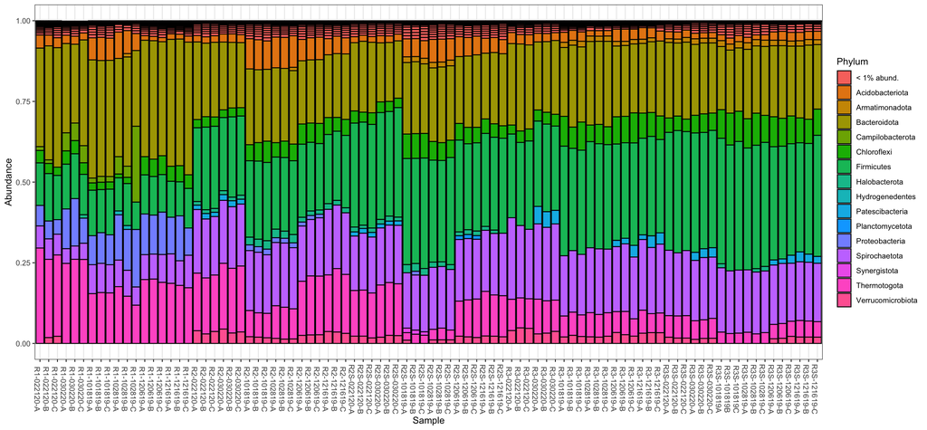

```r
p_unmerged <- tax_glom(ps.all_rel, taxrank="Phylum")
p_unmerged <- plot_bar(p_unmerged, fill = "Phylum")
data <- p_unmerged$data
data$Phylum <- as.character(data$Phylum)
data$Phylum[data$Abundance < 0.01] <- "< 1% abund."
p_unmerged$data <- data
p_unmerged <- ggplot(data=data, aes(x=Sample, y=Abundance, fill=Phylum))
p_unmerged <- p_unmerged + geom_bar(aes(), stat="identity", position="stack", colour="black")  + theme(axis.text.x = element_text(angle = 270))
p_unmerged
```

merge replicates

```r
ps_merged <- merge_samples(ps.all, "merge")
ps_merged <- prune_taxa(taxa_sums(ps_merged) > 1, ps_merged) #remove singletons
#fix merging turning factors into numbers
sample_data(ps_merged)$Sample <- sample_names(ps_merged)

#relative abundance, filter out taxa that have mean >0.00001
ps_merged.rel <- transform_sample_counts(ps_merged, function(x) x/sum(x))
ps_merged.filt <- filter_taxa(ps_merged.rel, function(x) mean(x) > 1e-5, TRUE)
```

## Exploratory analysis

### Bar Plots

bar plot- all samples, merged, phylum level

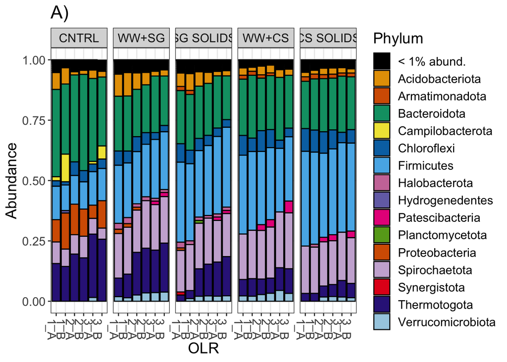

```r
p_all <- tax_glom(ps_merged.rel, taxrank="Phylum")
p_all <- plot_bar(p_all, fill = "Phylum")
data <- p_all$data
data$Phylum <- as.character(data$Phylum)
data$Phylum[data$Abundance < 0.01] <- "< 1% abund."
data <- data %>%
  mutate(OLR_3, OLR_3 = case_when(as.character(OLR_3) == "1"~"1_A", as.character(OLR_3) =="2"~"1_B", as.character(OLR_3) =="3"~"2_A", as.character(OLR_3) =="4"~"2_B", as.character(OLR_3) =="5"~"3_A", as.character(OLR_3) =="6"~"3_B", TRUE ~ as.character(OLR_3)))
data <- data  %>%
  mutate(reactor_2, reactor_2 = case_when(as.character(reactor_2) == "1"~"CNTRL", as.character(reactor_2) =="2"~"CS SOLIDS", as.character(reactor_2) =="3"~"SG SOLIDS", as.character(reactor_2) =="4"~"WW+CS", as.character(reactor_2) =="5"~"WW+SG", TRUE ~ as.character(reactor_2)))
data <- data %>%
  mutate(reactor_2 = factor(reactor_2, levels = c("CNTRL", "WW+SG", "SG SOLIDS", "WW+CS", "CS SOLIDS")))
p_all$data <- data
p_all <- ggplot(data=data, aes(x=OLR_3, y=Abundance, fill=Phylum))
p_all <- p_all + geom_bar(aes(), stat="identity", position="stack", colour="black") + labs(title= "A)") + facet_wrap(~reactor_2, nrow=1) +
   scale_fill_manual(values = cbPalette) +   theme(axis.text.x = element_text(angle = 270)) + xlab("OLR") + theme(text = element_text(size =15))
p_all
```

bar plot- all samples, merged, class level

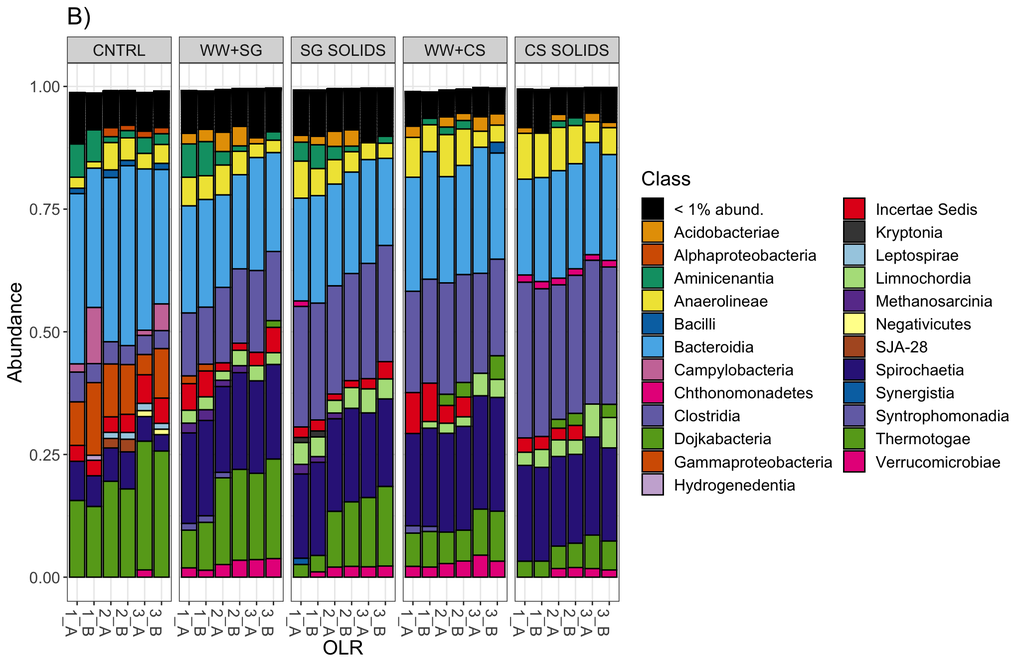

```r
p_all_class <- tax_glom(ps_merged.rel, taxrank="Class")
p_all_class <- plot_bar(p_all_class, fill = "Class")
data <- p_all_class$data
data$Class <- as.character(data$Class)
data$Class[data$Abundance < 0.01] <- "< 1% abund."
data <- data %>%
  mutate(OLR_3, OLR_3 = case_when(as.character(OLR_3) == "1"~"1_A", as.character(OLR_3) =="2"~"1_B", as.character(OLR_3) =="3"~"2_A", as.character(OLR_3) =="4"~"2_B", as.character(OLR_3) =="5"~"3_A", as.character(OLR_3) =="6"~"3_B", TRUE ~ as.character(OLR_3)))
data <- data  %>%
  mutate(reactor_2, reactor_2 = case_when(as.character(reactor_2) == "1"~"CNTRL", as.character(reactor_2) =="2"~"CS SOLIDS", as.character(reactor_2) =="3"~"SG SOLIDS", as.character(reactor_2) =="4"~"WW+CS", as.character(reactor_2) =="5"~"WW+SG", TRUE ~ as.character(reactor_2)))
data <- data %>%
  mutate(reactor_2 = factor(reactor_2, levels = c("CNTRL", "WW+SG", "SG SOLIDS", "WW+CS", "CS SOLIDS")))
p_all_class$data <- data
p_all_class <- ggplot(data=data, aes(x=OLR_3, y=Abundance, fill=Class))
p_all_class <- p_all_class + labs(title= "B)") + geom_bar(aes(), stat="identity", position="stack", colour="black") + facet_wrap(~reactor_2, nrow=1) +
  scale_fill_manual(values = cbPalette3) +   theme(axis.text.x = element_text(angle = 270)) + xlab("OLR") + theme(text = element_text(size =15)) + theme(plot.title = element_text(hjust = 0))
p_all_class
```

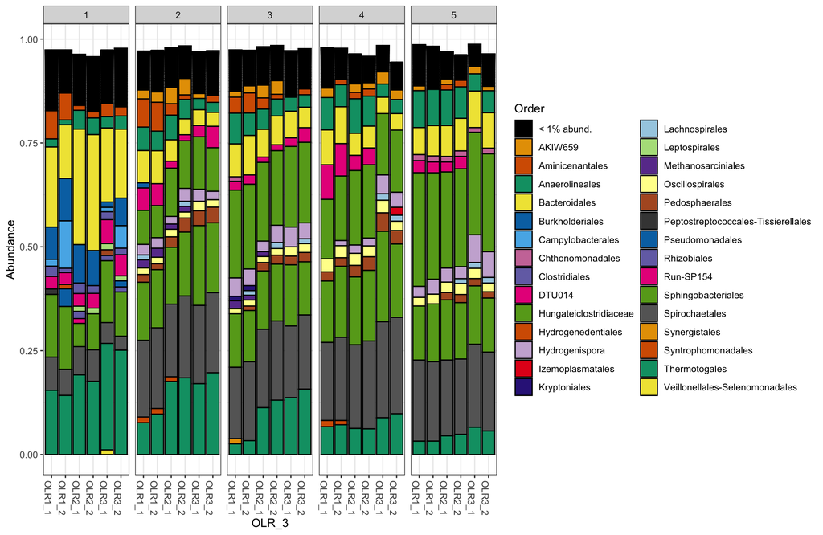

```r
p_all_order <- tax_glom(ps_merged.rel, taxrank="Order")
p_all_order <- plot_bar(p_all_order, fill = "Order")
data <- p_all_order$data
data$Order <- as.character(data$Order)
data$Order[data$Abundance < 0.01] <- "< 1% abund."
data <- data %>%
  mutate(OLR_3, OLR_3 = case_when(as.character(OLR_3) == "1"~"OLR1_1", as.character(OLR_3) =="2"~"OLR1_2", as.character(OLR_3) =="3"~"OLR2_1", as.character(OLR_3) =="4"~"OLR2_2", as.character(OLR_3) =="5"~"OLR3_1", as.character(OLR_3) =="6"~"OLR3_2", TRUE ~ as.character(OLR_3)))
data <- data  %>%
  mutate(reactor_2, reactor_2 = case_when(as.character(reactor_2) == "1"~"CNTRL", as.character(reactor_2) =="2"~"CS SOLIDS", as.character(reactor_2) =="3"~"SG SOLIDS", as.character(reactor_2) =="4"~"WW+CS", as.character(reactor_2) =="5"~"WW+SG", TRUE ~ as.character(reactor_2)))
data <- data %>%
  mutate(reactor_2 = factor(reactor_2, levels = c("CNTRL", "WW+SG", "SG SOLIDS", "WW+CS", "CS SOLIDS")))
p_all_order$data <- data
p_all_order <- ggplot(data=data, aes(x=OLR_3, y=Abundance, fill=Order))
p_all_order <- p_all_order + geom_bar(aes(), stat="identity", position="stack", colour="black") + facet_wrap(~Reactor, nrow=1) +
  scale_fill_manual(values = cbPalette) +   theme(axis.text.x = element_text(angle = 270))
p_all_order
```

Archaea (methanogens)

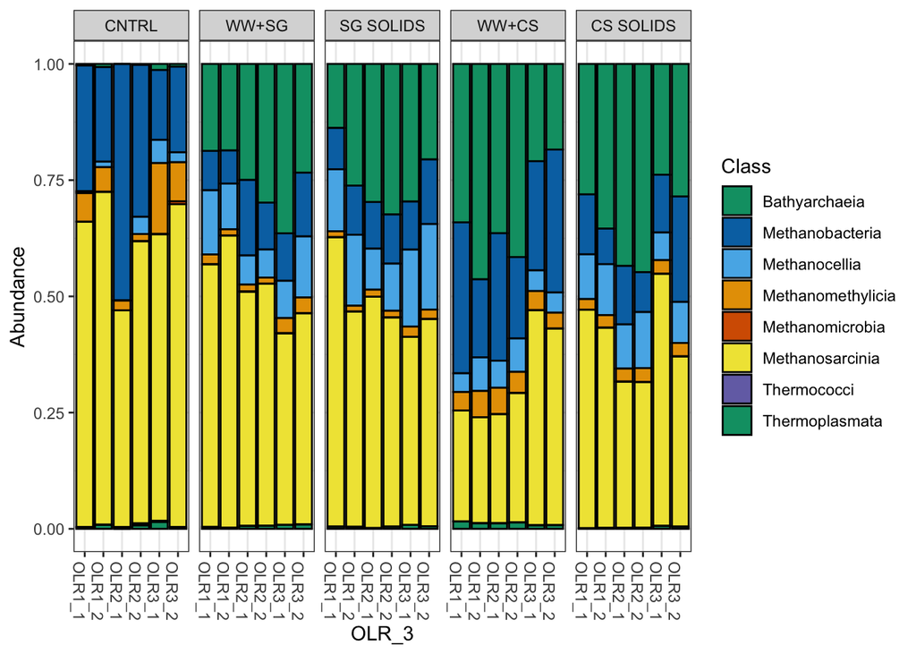

```r
ps_methano <- subset_taxa(ps_merged, Kingdom == "Archaea")
ps_methano_rel <- transform_sample_counts(ps_methano, function(x) x/sum(x))
p_methano <- tax_glom(ps_methano_rel, taxrank="Class")
p_methano <- plot_bar(p_methano, fill = "Class")
data <- p_methano$data
data <- data %>%
  mutate(OLR_3, OLR_3 = case_when(as.character(OLR_3) == "1"~"OLR1_1", as.character(OLR_3) =="2"~"OLR1_2", as.character(OLR_3) =="3"~"OLR2_1", as.character(OLR_3) =="4"~"OLR2_2", as.character(OLR_3) =="5"~"OLR3_1", as.character(OLR_3) =="6"~"OLR3_2", TRUE ~ as.character(OLR_3)))
data <- data  %>%
  mutate(reactor_2, reactor_2 = case_when(as.character(reactor_2) == "1"~"CNTRL", as.character(reactor_2) =="2"~"CS SOLIDS", as.character(reactor_2) =="3"~"SG SOLIDS", as.character(reactor_2) =="4"~"WW+CS", as.character(reactor_2) =="5"~"WW+SG", TRUE ~ as.character(reactor_2)))
data <- data %>%
  mutate(reactor_2 = factor(reactor_2, levels = c("CNTRL", "WW+SG", "SG SOLIDS", "WW+CS", "CS SOLIDS")))
p_methano$data <- data
p_methano <- ggplot(data=data, aes(x=OLR_3, y=Abundance, fill=Class))
p_methano <- p_methano + geom_bar(aes(), stat="identity", position="stack", colour="black") + facet_wrap(~reactor_2, nrow=1) +
  scale_fill_manual(values = cbPalette2) +   theme(axis.text.x = element_text(angle = 270))
p_methano
```

### Ordination

clr transform the dataset to normalize– log ratio of sample divided by geometric mean of all samples. Ratio transformations capture relationship between features in the dataset and the ratios are the sample whether the data are counts or proportions. Log ratio makes the data symmetric and linearly related and places data in a log-ratio coordinate space. (Gloor et al., 2017)

```r
ps.clr <- prune_samples(sample_data(ps.nocontam)$Reactor != "MOCK", ps.nocontam)
ps.clr <- prune_samples(sample_data(ps.clr)$Reactor != "NEGCONTROL", ps.clr)
asv.onlysamples <- as(otu_table(ps.clr), "matrix")
asv.onlysamples = as.data.frame(asv.onlysamples)
clr <- clr(asv.onlysamples)
clr <- as.data.frame(clr)
min(clr) #-3.37
```

```
## [1] -3.370143
```

```r
clr <- clr + 4
```

NMDS using bray-curtis dissimilarity distance with clr-transformed data

```r
ord1 <- metaMDS(clr, distance = "bray", trymax=99, autotransform = FALSE)
```

stressplot shows good fit of the data

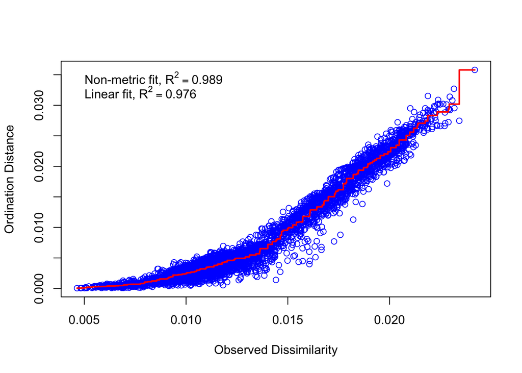

```r
stressplot(ord1)
```

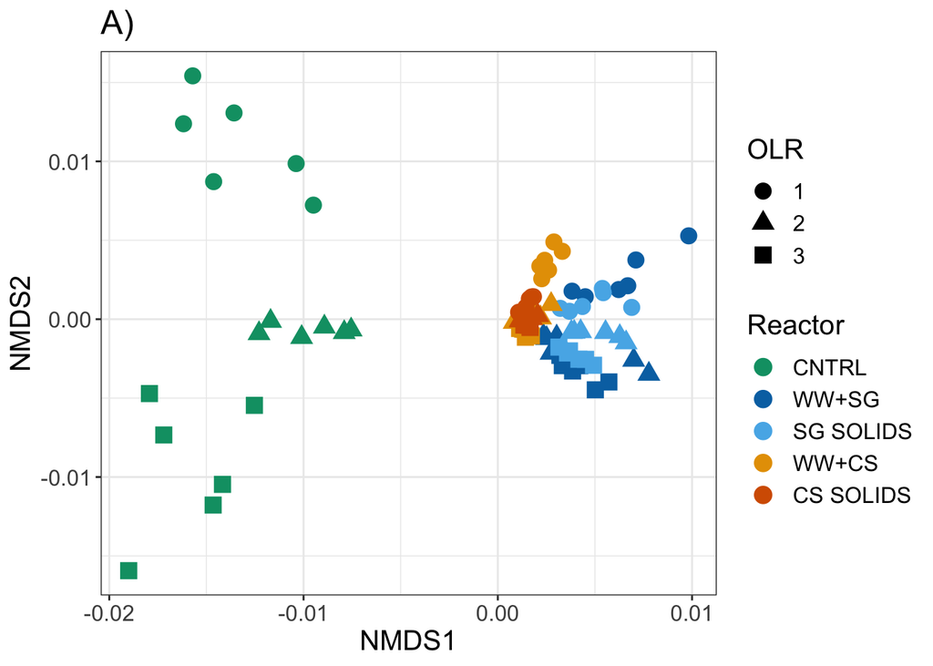

```r
p1_ord1 <- plot_ordination(ps.clr, ord1, type="samples", color="Reactor", shape="OLR")
data <- p1_ord1$data
data <- data  %>%
  mutate(Reactor, Reactor = case_when(as.character(Reactor) == "1"~"CNTRL", as.character(Reactor) =="2"~"WW+SG", as.character(Reactor) =="2S"~"SG SOLIDS", as.character(Reactor) =="3"~"WW+CS", as.character(Reactor) =="3S"~"CS SOLIDS", TRUE ~ as.character(Reactor)))
data <- data %>%
  mutate(Reactor = factor(Reactor, levels = c("CNTRL", "WW+SG", "SG SOLIDS", "WW+CS", "CS SOLIDS")))
p1_ord1$data <- data
p1_ord1 <- p1_ord1 + geom_point(size=4) +
   theme(text = element_text(size =15)) +
  scale_color_manual(values = cbPalette2) +  labs(title= "A)")
p1_ord1
```

Same for co-digester samples only

```r
ps.co <- prune_samples(sample_data(ps.clr)$Reactor != "1", ps.clr) #remove control samples
asv.onlysamples <- as(otu_table(ps.co), "matrix")
asv.onlysamples = as.data.frame(asv.onlysamples)
clr <- clr(asv.onlysamples)
clr <- as.data.frame(clr)
min(clr)
```

```
## [1] -3.370143
```

```r
clr <- clr + 4
```

```r
ord2 <- metaMDS(clr, distance = "bray", trymax=99, autotransform = FALSE)
```

stressplot shows good fit of the data

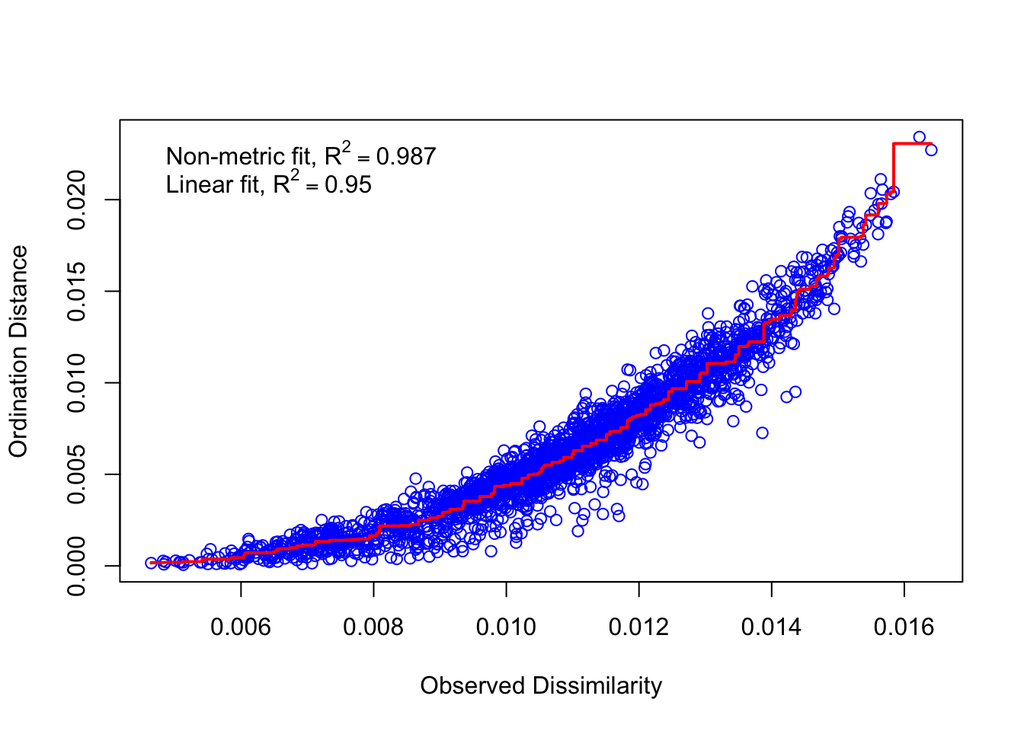

```r
stressplot(ord2)
```

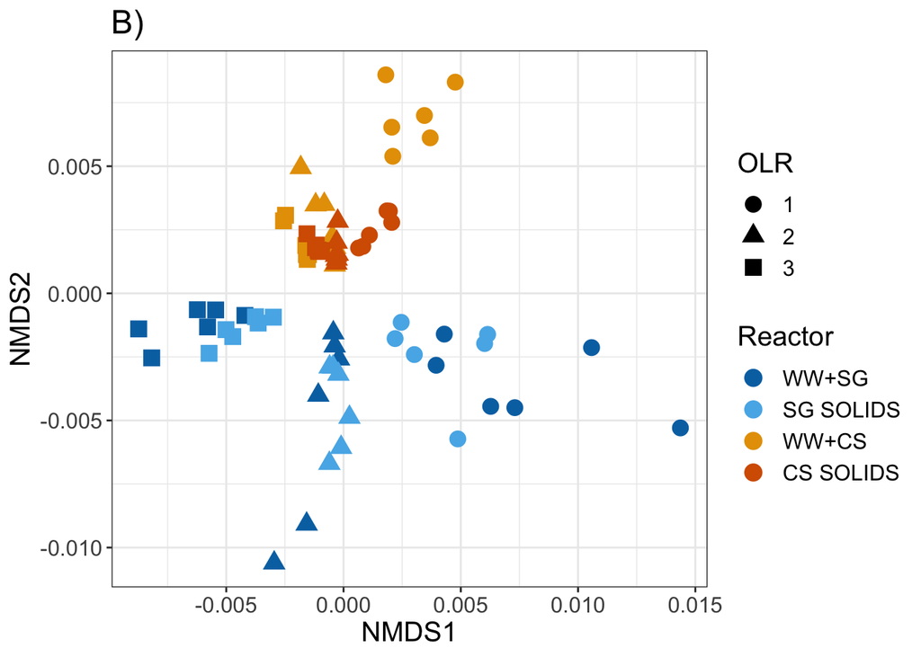

```r
p1_ord2 <- plot_ordination(ps.co, ord2, type="samples", color="Reactor", shape="OLR")
data <- p1_ord2$data
data <- data  %>%
  mutate(Reactor, Reactor = case_when(as.character(Reactor) =="2"~"WW+SG", as.character(Reactor) =="2S"~"SG SOLIDS", as.character(Reactor) =="3"~"WW+CS", as.character(Reactor) =="3S"~"CS SOLIDS", TRUE ~ as.character(Reactor)))
data <- data %>%
  mutate(Reactor = factor(Reactor, levels = c("WW+SG", "SG SOLIDS", "WW+CS", "CS SOLIDS")))
p1_ord2$data <- data
p1_ord2 <- p1_ord2 + geom_point(size=4) +
   theme(text = element_text(size =15)) +
  scale_color_manual(values = cbPalette4) + labs(title= "B)")
p1_ord2
```

## Differential Abundance

### ANCOM

ANCOM (analysis of composition of microbiomes). Pair-wise tests on the log-ratio of ASVs. (Mandal et al., 2015)

#### WW+SG vs CNTRL

```r
#filter out unwanted samples
ps.SG.CNTRL <- prune_samples(sample_data(ps.all)$Reactor != "3S", ps.all)
ps.SG.CNTRL <- prune_samples(sample_data(ps.SG.CNTRL)$Reactor != "3", ps.SG.CNTRL)
ps.SG.CNTRL <- prune_samples(sample_data(ps.SG.CNTRL)$Reactor != "2S", ps.SG.CNTRL)

asv.SG.CNTRL <- t(as(otu_table(ps.SG.CNTRL), "matrix")) #format asv matrix
meta.R2.1 <- read.csv("R2_1_meta.csv", header=TRUE) #import metadata
meta_data <- (meta.R2.1)

feature_table = asv.SG.CNTRL; sample_var = "X.NAME"; group_var = NULL #sample_var=column in metadata table with sample names, group_var= OLR
out_cut = 0.05; zero_cut = 0.90; lib_cut = 0; neg_lb = FALSE #out_cut= each taxon with proportion of mixture distribution less than out_cut are outlier zeros and those with 1- out_cut are outlier values; zero_cut= taxa with proportion of 0s greater than zero_cut are not included; lib_cut= libraries size less than not included. Want to include all so =0
prepro = feature_table_pre_process(feature_table, meta_data, sample_var, group_var,
                                   out_cut, zero_cut, lib_cut, neg_lb)
feature_table = prepro$feature_table # Preprocessed feature table
meta_data = prepro$meta_data # Preprocessed metadata
struc_zero = prepro$structure_zeros # Structural zero info

main_var = "Reactor"; p_adj_method = "BH"; alpha = 0.05 ; adj_formula = "OLR" ; rand_formula=NULL #adj_formula- account for differences in organic loading rate

res = ANCOM(feature_table, meta_data, struc_zero, main_var, p_adj_method,
            alpha, adj_formula, rand_formula)
```

#### WW+CS vs CNTRL

```r
ps.CS.CNTRL <- prune_samples(sample_data(ps.all)$Reactor != "2S", ps.all)
ps.CS.CNTRL <- prune_samples(sample_data(ps.CS.CNTRL)$Reactor != "2", ps.CS.CNTRL)
ps.CS.CNTRL <- prune_samples(sample_data(ps.CS.CNTRL)$Reactor != "3S", ps.CS.CNTRL)

asv.CS.CNTRL <- t(as(otu_table(ps.CS.CNTRL), "matrix")) #format asv matrix
meta.R3.1 <- read.csv("R3_1_meta.csv", header=TRUE) #import metadata
meta_data <- (meta.R3.1)

feature_table = asv.CS.CNTRL; sample_var = "X.NAME"; group_var = NULL #sample_var=column in metadata table with sample names, group_var= OLR
out_cut = 0.05; zero_cut = 0.90; lib_cut = 0; neg_lb = FALSE #out_cut= each taxon with proportion of mixture distribution less than out_cut are outlier zeros and those with 1- out_cut are outlier values; zero_cut= taxa with proportion of 0s greater than zero_cut are not included; lib_cut= libraries size less than not included. Want to include all so =0; neg_lb=
prepro = feature_table_pre_process(feature_table, meta_data, sample_var, group_var,
                                   out_cut, zero_cut, lib_cut, neg_lb)
feature_table = prepro$feature_table # Preprocessed feature table
meta_data = prepro$meta_data # Preprocessed metadata
struc_zero = prepro$structure_zeros # Structural zero info

main_var = "Reactor"; p_adj_method = "BH"; alpha = 0.05 ; adj_formula = "OLR" ; rand_formula=NULL

res = ANCOM(feature_table, meta_data, struc_zero, main_var, p_adj_method,
            alpha, adj_formula, rand_formula)
```

#### WW+SG vs SG SOLIDS

```r
ps.SG.SOLIDS <- prune_samples(sample_data(ps.all)$Reactor != "1", ps.all)
ps.SG.SOLIDS <- prune_samples(sample_data(ps.SG.SOLIDS)$Reactor != "3S", ps.SG.SOLIDS)
ps.SG.SOLIDS <- prune_samples(sample_data(ps.SG.SOLIDS)$Reactor != "3", ps.SG.SOLIDS)

asv.SG.SOLIDS <- t(as(otu_table(ps.SG.SOLIDS), "matrix"))
meta.R2 <- read.csv("R2_meta.csv", header=TRUE)
meta_data <- (meta.R2)

feature_table = asv.SG.SOLIDS; sample_var = "X.NAME"; group_var = NULL
out_cut = 0.05; zero_cut = 0.90; lib_cut = 0; neg_lb = FALSE
prepro = feature_table_pre_process(feature_table, meta_data, sample_var, group_var,
                                   out_cut, zero_cut, lib_cut, neg_lb)
feature_table = prepro$feature_table # Preprocessed feature table
meta_data = prepro$meta_data # Preprocessed metadata
struc_zero = prepro$structure_zeros # Structural zero info

main_var = "Reactor"; p_adj_method = "BH"; alpha = 0.05 ; adj_formula = "OLR" ; rand_formula=NULL

res = ANCOM(feature_table, meta_data, struc_zero, main_var, p_adj_method,
            alpha, adj_formula, rand_formula)

head(res$out)
```

|  | taxa_id | W | detected_0.9 | detected_0.8 | detected_0.7 | detected_0.6 |
| --- | --- | --- | --- | --- | --- | --- |
| 1 | ASV1 | 156 | FALSE | FALSE | FALSE | FALSE |
| 2 | ASV2 | 268 | FALSE | FALSE | FALSE | FALSE |
| 3 | ASV3 | 115 | FALSE | FALSE | FALSE | FALSE |
| 4 | ASV4 | 113 | FALSE | FALSE | FALSE | FALSE |
| 5 | ASV5 | 129 | FALSE | FALSE | FALSE | FALSE |
| 6 | ASV6 | 775 | TRUE | TRUE | TRUE | TRUE |

#### WW+CS vs CS SOLIDS

```r
ps.CS.SOLIDS <- prune_samples(sample_data(ps.all)$Reactor != "1", ps.all)
ps.CS.SOLIDS <- prune_samples(sample_data(ps.CS.SOLIDS)$Reactor != "2S", ps.CS.SOLIDS)
ps.CS.SOLIDS <- prune_samples(sample_data(ps.CS.SOLIDS)$Reactor != "2", ps.CS.SOLIDS)

asv.CS.SOLIDS <- t(as(otu_table(ps.CS.SOLIDS), "matrix"))
meta.R3 <- read.csv("R3_meta.csv", header=TRUE)
meta_data <- (meta.R3)

feature_table = asv.CS.SOLIDS; sample_var = "X.NAME"; group_var = NULL ;
out_cut = 0.05; zero_cut = 0.90; lib_cut = 0; neg_lb = FALSE
prepro = feature_table_pre_process(feature_table, meta_data, sample_var, group_var,
                                   out_cut, zero_cut, lib_cut, neg_lb)
feature_table = prepro$feature_table # Preprocessed feature table
meta_data = prepro$meta_data # Preprocessed metadata
struc_zero = prepro$structure_zeros # Structural zero info

main_var = "Reactor"; p_adj_method = "BH"; alpha = 0.05 ; adj_formula = "OLR" ; rand_formula=NULL

res = ANCOM(feature_table, meta_data, struc_zero, main_var, p_adj_method,
            alpha, adj_formula, rand_formula)

head(res$out)
```

|  | taxa_id | W | detected_0.9 | detected_0.8 | detected_0.7 | detected_0.6 |
| --- | --- | --- | --- | --- | --- | --- |
| 1 | ASV1 | 192 | FALSE | FALSE | FALSE | FALSE |
| 2 | ASV2 | 196 | FALSE | FALSE | FALSE | FALSE |
| 3 | ASV3 | 172 | FALSE | FALSE | FALSE | FALSE |
| 4 | ASV4 | 172 | FALSE | FALSE | FALSE | FALSE |
| 5 | ASV5 | 142 | FALSE | FALSE | FALSE | FALSE |
| 6 | ASV6 | 531 | FALSE | TRUE | TRUE | TRUE |

### ANCOM-BC

ANCOM-BC (analysis of compositions of microbiome with bias correction). Corrects bias introduced from unknown sampling fractions by introducing a sample-specific offset term to the linear regression framework. Linear regression is in log-scale. (Lin and Peddada, 2020) #### WW+SG vs CNTRL

```r
out = ancombc(phyloseq=ps.SG.CNTRL, formula= "Reactor + OLR", p_adj_method = "holm", zero_cut = 0.90, lib_cut = 0, group= NULL, struc_zero = FALSE, neg_lb= FALSE, tol = 1e-5, max_iter=100, alpha=0.05, global= FALSE)
res= out$res
diff_abn <- res$diff_abn
head(diff_abn)
```

|  | Reactor2 | OLR2 | OLR3 |
| --- | --- | --- | --- |
| ASV1 | TRUE | FALSE | FALSE |
| ASV2 | FALSE | TRUE | TRUE |
| ASV3 | TRUE | TRUE | FALSE |
| ASV4 | TRUE | TRUE | FALSE |
| ASV5 | TRUE | FALSE | FALSE |
| ASV6 | TRUE | FALSE | FALSE |

#### WW+CS vs CNTRL

```r
out = ancombc(phyloseq=ps.CS.CNTRL, formula= "Reactor + OLR", p_adj_method = "holm", zero_cut = 0.90, lib_cut = 0, group= NULL, struc_zero = FALSE, neg_lb= FALSE, tol = 1e-5, max_iter=100, alpha=0.05, global= FALSE)
res= out$res
diff_abn <- res$diff_abn
head(diff_abn)
```

|  | Reactor3 | OLR2 | OLR3 |
| --- | --- | --- | --- |
| ASV1 | TRUE | FALSE | FALSE |
| ASV2 | TRUE | FALSE | TRUE |
| ASV3 | TRUE | TRUE | FALSE |
| ASV4 | TRUE | TRUE | FALSE |
| ASV5 | TRUE | FALSE | FALSE |
| ASV6 | TRUE | FALSE | FALSE |

#### WW+SG vs SG SOLIDS

```r
out = ancombc(phyloseq=ps.SG.SOLIDS, formula= "Reactor + OLR", p_adj_method = "holm", zero_cut = 0.90, lib_cut = 0, group= NULL, struc_zero = FALSE, neg_lb= FALSE, tol = 1e-5, max_iter=100, alpha=0.05, global= FALSE)
res= out$res
diff_abn.2 <- res$diff_abn
head(diff_abn.2)
```

|  | Reactor2S | OLR2 | OLR3 |
| --- | --- | --- | --- |
| ASV1 | TRUE | TRUE | TRUE |
| ASV2 | TRUE | TRUE | TRUE |
| ASV3 | FALSE | FALSE | FALSE |
| ASV4 | FALSE | TRUE | TRUE |
| ASV5 | TRUE | TRUE | TRUE |
| ASV6 | TRUE | FALSE | TRUE |

#### WW+CS vs CS SOLIDS

```r
out = ancombc(phyloseq=ps.CS.SOLIDS, formula= "Reactor + OLR", p_adj_method = "holm", zero_cut = 0.90, lib_cut = 0, group= NULL, struc_zero = FALSE, neg_lb= FALSE, tol = 1e-5, max_iter=100, alpha=0.05, global= FALSE)
res= out$res
diff_abn.3 <- res$diff_abn
head(diff_abn.3)
```

|  | Reactor3S | OLR2 | OLR3 |
| --- | --- | --- | --- |
| ASV1 | TRUE | FALSE | TRUE |
| ASV2 | TRUE | FALSE | TRUE |
| ASV3 | FALSE | FALSE | TRUE |
| ASV4 | FALSE | FALSE | TRUE |
| ASV5 | TRUE | TRUE | TRUE |
| ASV6 | TRUE | FALSE | FALSE |